# The Impact of Aging on Cognitive Decline: A Longitudinal Study Using Linear Mixed Models

Author

Adasia McClinton

# 1 Introduction

Cognitive decline in aging populations is a critical concern for researchers in neuroscience, psychology, and public health. As the global population ages, understanding the factors that contribute to cognitive deterioration becomes increasingly vital for developing effective interventions. Cognitive decline is not uniform; it is influenced by various demographic, health, and socioeconomic factors, which interact in complex ways. Consequently, traditional statistical methods, such as linear regression and ANOVA, often fall short in accurately modeling these dynamics due to their inability to handle hierarchical and correlated data structures.

Linear Mixed Models (LMMs) have emerged as a powerful statistical tool for analyzing such complex data. Unlike traditional methods, LMMs can accommodate both fixed effects, which capture population-level trends, and random effects, which account for individual or group-level variability. This dual capability allows LMMs to model intra-individual and inter-individual differences simultaneously, making them particularly suited for longitudinal and hierarchical datasets. Bates (2014) underscores the utility of LMMs in capturing within-group correlations and managing data with unequal numbers of observations across participants.

LMMs also excel in handling missing data, a common challenge in longitudinal studies. Traditional approaches, such as listwise deletion and mean imputation, risk introducing bias and reducing statistical power. However, Meteyard and Davies (2020) highlight that LMMs effectively address missing data under the Missing at Random (MAR) assumption by utilizing maximum likelihood estimation (MLE) or restricted maximum likelihood estimation (REML). This enables researchers to include all available data, enhancing the accuracy of their findings.

The application of LMMs spans various disciplines, including psychology, ecology, and medicine. In ecological studies, Bolker (2015) illustrates how LMMs manage data collected across multiple sites and time periods, providing nuanced insights into environmental processes. In psychology, LMMs are employed to analyze repeated measures data, capturing the complexities of cognitive processes over time. These models also play a crucial role in medical research, where they are used to study longitudinal health outcomes, such as changes in cognitive function and quality of life in patients with chronic conditions.

This study leverages the strengths of LMMs to investigate the relationship between aging and cognitive function, focusing on Mini-Mental State Examination (MMSE) scores. Specifically, it explores how age, dementia status, and socioeconomic factors interact to influence cognitive decline. By modeling these interactions, this research aims to provide a comprehensive understanding of the trajectories of cognitive aging across different demographic groups.

The findings of this study have important implications for public health and clinical practice. Understanding the patterns and predictors of cognitive decline can inform the development of targeted interventions to slow cognitive deterioration, particularly in vulnerable populations. This research contributes to the broader effort to address the challenges posed by an aging population, emphasizing the importance of advanced statistical methods like LMMs in capturing the complexity of real-world data.

[output not shown]

Table 1: Participant Characteristics by Group

|  | level | Converted | Demented | Nondemented | p | test | SMD |
| --- | --- | --- | --- | --- | --- | --- | --- |
| n |  | 37 | 146 | 190 |  |  |  |
| Age..mean..SD.. |  | 79.76 (7.43) | 76.26 (6.94) | 77.06 (8.10) | 0.045 |  | 0.313 |
| Gender…. | Female | 24 ( 64.9) | 60 ( 41.1) | 129 ( 67.9) | <0.001 |  | 0.371 |
| X | Male | 13 ( 35.1) | 86 ( 58.9) | 61 ( 32.1) |  |  |  |
| Hand…. | R | 37 (100.0) | 146 (100.0) | 190 (100.0) | NA |  | <0.001 |
| EDUC..mean..SD.. |  | 15.46 (2.52) | 13.67 (2.90) | 15.14 (2.74) | <0.001 |  | 0.433 |
| SES..mean..SD.. |  | 1.73 (0.96) | 2.77 (1.20) | 2.39 (1.05) | <0.001 |  | 0.652 |
| MMSE..mean..SD.. |  | 28.68 (1.56) | 24.51 (4.50) | 29.23 (0.88) | <0.001 |  | 1.041 |
| CDR…. | 0 | 18 ( 48.6) | 0 ( 0.0) | 188 ( 98.9) | <0.001 |  | 5.599 |
| X.1 | 0.5 | 19 ( 51.4) | 102 ( 69.9) | 2 ( 1.1) |  |  |  |
| X.2 | 1 | 0 ( 0.0) | 41 ( 28.1) | 0 ( 0.0) |  |  |  |
| X.3 | 2 | 0 ( 0.0) | 3 ( 2.1) | 0 ( 0.0) |  |  |  |
| eTIV..mean..SD.. |  | 1459.27 (135.43) | 1485.85 (173.77) | 1495.50 (184.89) | 0.510 |  | 0.149 |
| nWBV..mean..SD.. |  | 0.72 (0.04) | 0.72 (0.03) | 0.74 (0.04) | <0.001 |  | 0.465 |
| ASF..mean..SD.. |  | 1.21 (0.11) | 1.20 (0.14) | 1.19 (0.14) | 0.683 |  | 0.111 |

# 2 Methods

As discussed by Brown (2021), a Linear Mixed Model (LMM) is:

*a parametric linear model for clustered, longitudinal, or repeated-measures data that quantifies the relationships between a continuous dependent variable and various predictor variables. LMMs typically consist of fixed-effect parameters, which are associated with one or more covariates, and random effects, which account for variability across different clusters or subjects.*

In the context of this study, fixed-effect parameters describe the relationship of the covariates (such as age) to the dependent variable (MMSE score) across the entire population. Meanwhile, random effects account for individual variability across participants. This structure allows us to model both within-subject (repeated measures) and between-subject (individual) variations.

The dataset used in this study contains longitudinal data, where the MMSE score, our continuous dependent variable, is measured at multiple time points for each participant. Longitudinal data often require careful handling due to issues like participant dropout, which can cause later time points to have fewer observations compared to earlier ones. Alongside this, the hierarchical nature of longitudinal data makes it suitable for analysis using LMMs, which can model such structured dependencies.

## 2.1 Mathematical Foundation

LMMs rely on a strong mathematical foundation based on linear algebra. The general formulation for a 2-level longitudinal model, as applied in this study, is given by the following equation:

$$Y = X\beta + Z u + \epsilon$$

Where:

- Y is the response vector, representing the dependent variable (MMSE scores).
- X is the design matrix for fixed effects (such as age and gender).
- \( \beta \) is the vector of fixed effects, representing the population-level parameters.
- Z is the design matrix for random effects (subject-level variability).
- u is the vector of random effects, which accounts for individual variability.
- ϵ is the vector of residual errors.

### 2.1.1 Estimation Method

  We used **Restricted Maximum Likelihood Estimation (REML)** to estimate the model parameters. REML was chosen because it reduces bias in the estimation of variance components, particularly for the random effects.

## 2.2 Assumptions

The LMM assumes:

- **Linearity**: The relationship between the predictors and the outcome variable is assumed to be linear.
- **Normality**: Both random effects and residual errors are assumed to be normally distributed.
- **Independence**: Random effects and residuals are assumed to be independent from one another.
- **Homoscedasticity**: The variance of residuals is assumed to be constant across all levels of the predictors.

## 2.3 Implementation

The data were preprocessed to handle any missing values before fitting the models. All analyses were conducted using the `lme4` package in **R**, and model diagnostics were performed to ensure that the assumptions of the LMM were met. Graphical representations and visual diagnostics were created using the `ggplot2` package.

## 2.4 Implementation in R

The implementation of the LMM involved a series of steps, including initial model specification, hypothesis testing, and iterative model refinement. All analyses were conducted in R, utilizing the lme4 package, which is optimized for mixed-effects models and offers efficient handling of random effects (Bates et al., 2015). The process was divided into stages as outlined below.

### 2.4.1 Hypothesis Testing

Hypothesis testing was integral to refining the model and involved assessing the significance of each predictor to guide model development. Key hypotheses tested included:

- **Hypothesis 1**: Age is a significant predictor of cognitive decline.
- **Hypothesis 2**: Dementia severity (CDR) significantly impacts MMSE scores.
- **Hypothesis 3**: Brain volume (nWBV) is associated with cognitive function.

Likelihood ratio tests were used to compare nested models and evaluate the contribution of each predictor. Fixed effects that did not significantly improve model fit were considered for removal to streamline the model and improve interpretability.

### 2.4.2 Model Refinement

Based on the results of hypothesis testing, non-significant fixed effects, such as age and SES, were removed from the model to achieve parsimony. The refined model retained only the significant predictors, dementia severity (CDR) and normalized brain volume (nWBV), ensuring that the model focused on the factors most strongly associated with cognitive decline. This iterative refinement process enhanced the model’s clarity and interpretability.

### 2.4.3 Analysis Using lmer() Function

To finalize the analysis, the lmer() function from the lme4 package was used to fit the refined LMM. The lme4 package offers several advantages over nlme, particularly in terms of computational efficiency and the handling of crossed random effects Bates et al. (2014). The syntax and model structure were similar to those in lme(), but lme4 allowed for faster and more stable estimation, particularly beneficial for complex longitudinal data.

### 2.4.4 Final Model Selection

The final model was selected based on the results from both likelihood ratio tests and model diagnostics, which were reviewed to ensure that model assumptions were met. The final model specification included CDR and nWBV as fixed effects, with a random intercept for each subject to capture individual variability in MMSE scores. This final model provided a focused view of how dementia severity and brain volume are associated with cognitive decline, offering insights aligned with the study’s objectives.

## 3 Analysis and Results

This section provides a comprehensive overview of the analytical process, including data preparation, exploratory analysis, modeling, and prediction. The primary objective is to address the research question: How do age, dementia severity, and brain structure impact cognitive decline in older adults? Using the OASIS dataset, which includes cognitive assessments and MRI data for both demented and nondemented adults, we aimed to identify the primary factors influencing cognitive decline.

### 3.1 Packages

The following R packages were essential for this analysis:

- **lme4**: Used for fitting linear mixed models, which are critical for analyzing repeated measures data with both fixed and random effects. The lmer() function allowed us to include random intercepts for each subject, accounting for individual variability.
- **mice**: Used for handling missing data through multiple imputation, generating several complete datasets to improve the robustness of the findings.
- **mitml**: Employed for pooling model results across imputed datasets, ensuring reliable estimates and significance tests.
- **ggplot2**: For creating visualizations, including histograms, boxplots, QQ plots, and prediction plots, to support data exploration and result interpretation.

These packages provided the necessary tools for data management, modeling, and handling missing values, which strengthened the rigor of the analysis.

### 3.2 Data Preparation and Ingestion

The dataset, provided in CSV format, was loaded and examined to understand its structure. Key variables included demographic information (Age, Gender, Handedness), cognitive assessments (MMSE, CDR), and MRI metrics (eTIV, nWBV). Each row represented a single MRI session for a subject, capturing repeated visits over time, which allowed for longitudinal analysis.

```r
data <- read.csv("C:/IDC6940/IDC6940_BDP/oasis_longitudinal.csv")
```

#### 3.2.1 Handling Missing Values

Multiple imputation was applied to handle missing data in essential variables, such as MMSE, Age, and Group, ensuring that the analysis remained comprehensive and unbiased. The mice package was used to create five imputed datasets, each of which was modeled to ensure robustness against missing data.

#### 3.2.2 Exploratory Data Analysis

Table 2. Variable Description<sup>1</sup>

[output not shown]

<sup>1</sup> Each variable in the dataset, accompanied by a qualitative description from the study team.

To better understand the dataset, we conducted Exploratory Data Analysis (EDA) using visualizations:

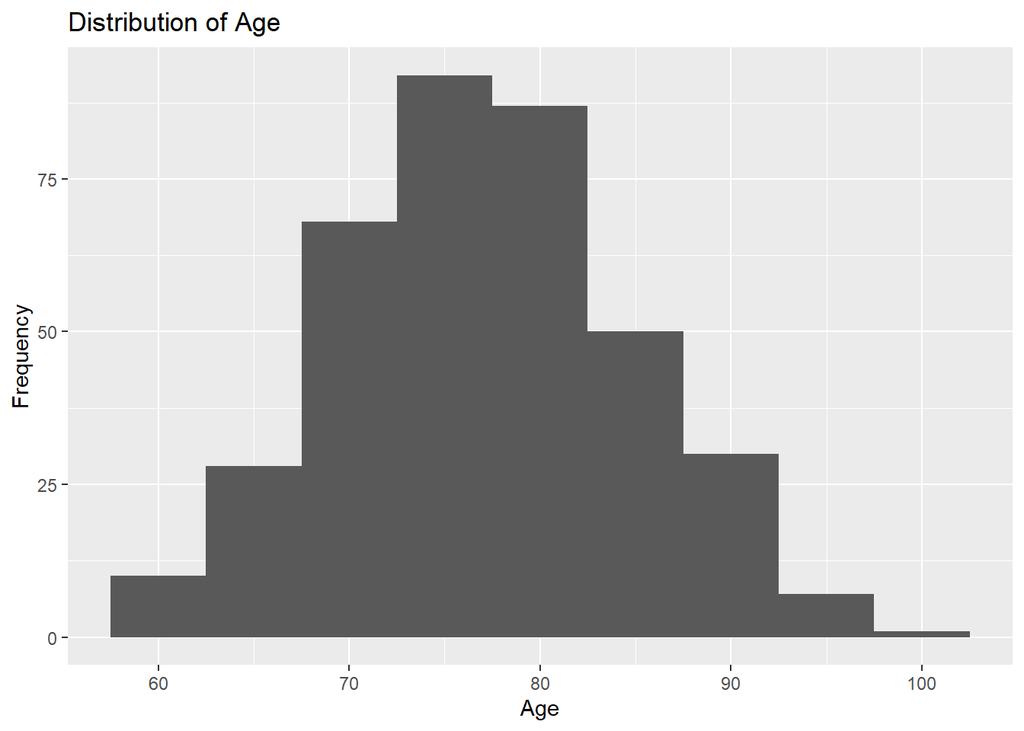

```r
library("ggplot2")
# Visualize distribution of Age
ggplot(data, aes(x = Age)) + geom_histogram(binwidth = 5) + labs(title = "Distribution of Age", x = "Age", y = "Frequency")
```

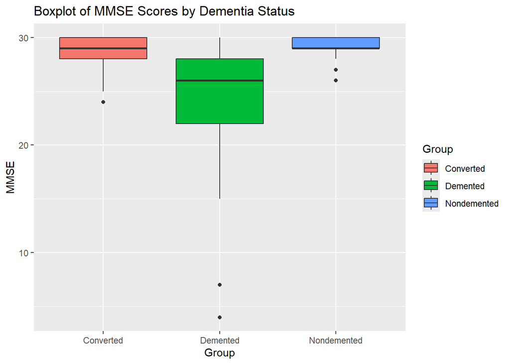

```r
# Boxplot of MMSE by Group (Dementia Status)
ggplot(data, aes(x = Group, y = MMSE, fill = Group)) + geom_boxplot() + labs(title = "Boxplot of MMSE Scores by Dementia Status", x = "Group", y = "MMSE")
```

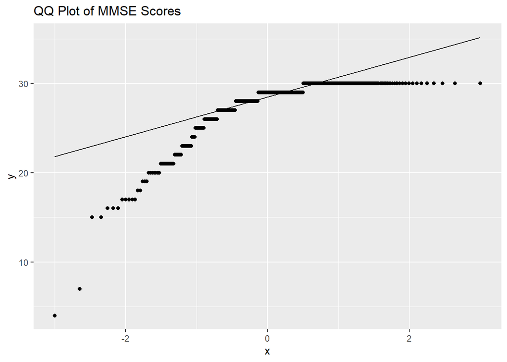

```r
# QQ Plot for MMSE to check normality
ggplot(data, aes(sample = MMSE)) + stat_qq() + stat_qq_line() + labs(title = "QQ Plot of MMSE Scores")
```

### 3.3 Linear Mixed Modeling

Linear Mixed Models (LMMs) were used to explore how age, dementia severity, and brain volume impact cognitive decline, with MMSE scores as the primary outcome to measure cognitive function. The longitudinal data structure enabled us to model individual cognitive trajectories over time.

#### 3.3.1 Model 0: Age as a Sole Predictor

As a baseline, we first fitted a simple model with age as the only predictor of MMSE scores, with Subject.ID as a random effect to account for individual variability. The model is expressed as follows:

```r
library("lme4")
library("mitml")
library("Matrix")
model0 <- lapply(imputed_list, function(data) lmer(MMSE ~ Age + (1 | Subject.ID), data = data))
pooled_results <- testEstimates(model0, method = "D2")
summary(pooled_results)
```

```
Call:

testEstimates(model = model0, method = "D2")

Final parameter estimates and inferences obtained from 5 imputed data sets.

             Estimate Std.Error   t.value        df   P(>|t|)       RIV       FMI
(Intercept)    29.859     2.454    12.167 9.143e+05     0.000     0.002     0.002
Age            -0.035     0.032    -1.094 6.477e+05     0.274     0.002     0.002

Unadjusted hypothesis test as appropriate in larger samples.
```

- **Results**: The age effect on MMSE was small and non-significant, suggesting that age alone does not fully explain cognitive decline.

#### 3.3.2 Model 1: Adding Dementia Status and SES

```r
model1 <- lapply(imputed_list, function(data) {
  lmer(MMSE ~ Age * Group + SES + (1 | Subject.ID), data = data)
})
pooled_results <- testEstimates(model1, method = "D2")
summary(pooled_results)
```

```
Call:

testEstimates(model = model1, method = "D2")

Final parameter estimates and inferences obtained from 5 imputed data sets.

                      Estimate Std.Error   t.value        df   P(>|t|)       RIV       FMI
(Intercept)             34.595     6.479     5.339 3.732e+05     0.000     0.003     0.003
Age                     -0.069     0.081    -0.858 4.112e+06     0.391     0.001     0.001
GroupDemented           -4.235     7.283    -0.581 1.863e+07     0.561     0.000     0.000
GroupNondemented        -4.198     6.957    -0.603 1.436e+07     0.546     0.001     0.001
SES                     -0.278     0.210    -1.324 9.895e+01     0.188     0.252     0.217
Age:GroupDemented        0.004     0.092     0.043 1.655e+07     0.966     0.000     0.000
Age:GroupNondemented     0.062     0.088     0.711 4.619e+06     0.477     0.001     0.001

Unadjusted hypothesis test as appropriate in larger samples.
```

- **Results**: This model showed no significant effects for age, SES, or age-by-group interactions, indicating that additional factors may better explain cognitive decline.

#### 3.3.3 Final Model with Significant Predictors Only

```r
final_model <- lapply(imputed_list, function(data) {
  lmer(MMSE ~ CDR + nWBV + (1 | Subject.ID), data = data)
})
pooled_final_results <- testEstimates(final_model, method = "D2")
summary(pooled_final_results)
```

```
Call:

testEstimates(model = final_model, method = "D2")

Final parameter estimates and inferences obtained from 5 imputed data sets.

             Estimate Std.Error   t.value        df   P(>|t|)       RIV       FMI
(Intercept)    17.680     3.662     4.828  6507.847     0.000     0.025     0.025
CDR            -5.272     0.482   -10.945   308.162     0.000     0.129     0.120
nWBV           15.277     4.941     3.092  7566.414     0.002     0.024     0.023

Unadjusted hypothesis test as appropriate in larger samples.
```

- **Results**: CDR was significantly associated with MMSE scores, showing that higher dementia severity leads to lower cognitive function. Additionally, higher nWBV was associated with higher MMSE, supporting its role in cognitive preservation.

### 3.4 Predictions and Visualizations

Using the final model, we generated predicted MMSE scores for a range of CDR and nWBV values to visualize cognitive trajectories across dementia severity and brain volume.

#### 3.4.1 Predicted MMSE by Dementia Severity (CDR) and Brain Volume (nWBV)

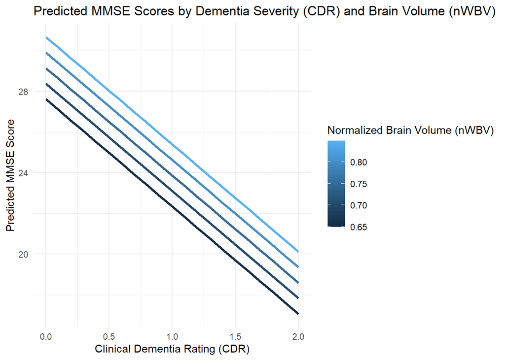

```r
#Define the new data for prediction
newdata <- expand.grid(CDR = seq(0, 2, 0.1), nWBV = seq(0.65, 0.85, 0.05))

# Generate predictions for each imputed model and store them
predictions <- sapply(final_model, function(model) predict(model, newdata = newdata, re.form = NA))

# Calculate the average prediction across all imputed models
newdata$predicted_MMSE <- rowMeans(predictions)

# Plot the predicted MMSE scores
library(ggplot2)
ggplot(newdata, aes(x = CDR, y = predicted_MMSE, color = nWBV, group = nWBV)) +
  geom_line(linewidth = 1.2) +
  scale_color_continuous(name = "Normalized Brain Volume (nWBV)") +
  labs(title = "Predicted MMSE Scores by Dementia Severity (CDR) and Brain Volume (nWBV)",
       x = "Clinical Dementia Rating (CDR)",
       y = "Predicted MMSE Score") +
  theme_minimal()
```

# 4 References

Bates, D., Mächler, M., Bolker, B., & Walker, S. (2014). Fitting linear mixed-effects models using lme4. *arXiv preprint*. https://doi.org/10.48550/arXiv.1406.5823

Brown, V. A. (2021). An introduction to linear mixed-effects modeling in R. *Advances in Methods and Practices in Psychological Science, 4*(1), 1–19. https://doi.org/10.1177/2515245920960351

Harris, J. (2019). *The great fear*. Oxford University Press.

Jaccard, J. J., Turrisi, R., & Wan, C. K. (2003). *Interaction effects in multiple regression* (2nd ed.). SAGE Publications.

McCulloch, C. E. (1996). An introduction to generalized linear mixed models. In *NSF-CBMS Regional Conference Series in Probability and Statistics* (Vol. 7). https://doi.org/10.1214/lnms/1215451825

Meteyard, L., & Davies, R. A. I. (2020). Best practice guidance for linear mixed-effects models in psychological science. *Journal of Memory and Language, 112*, 104092. https://doi.org/10.1016/j.jml.2020.104092

Starkweather, J. (2010). Linear mixed effects modeling using R. *Unpublished Manuscript*. https://doi.org/10.13140/RG.2.1.3420.4240

## References

Bates, Douglas, Martin Mächler, Ben Bolker, and Steve Walker. 2014. “Fitting Linear Mixed-Effects Models Using Lme4,” June. https://arxiv.org/abs/1406.5823.

Brown, Violet A. 2021. “An Introduction to Linear Mixed-Effects Modeling in r.” *Advances in Methods and Practices in Psychological Science* 4 (1): 1–19. https://doi.org/10.1177/2515245920960351.